# Analytical Queries and report

Madhavi Arvind Saraf

20-04-2023

```r
if (!require("RMySQL")) install.packages("RMySQL")
library(RMySQL)

# 2. Settings
db_user <- 'root'
db_password <- 'root'
db_name <- 'journaldw'
db_host <- 'localhost'
db_port <- 3306
dbConnectionMysql <-  dbConnect(MySQL(), user = db_user, password = db_password,host = db_host, port = db_port)
useDBqry <- paste0("USE ",db_name)
dbExecute(dbConnectionMysql,useDBqry)
```

```
## [1] 0
```

# Report

## Top five journals with the most articles published in them between 1975 - 1979

## Date : 20 April 2023

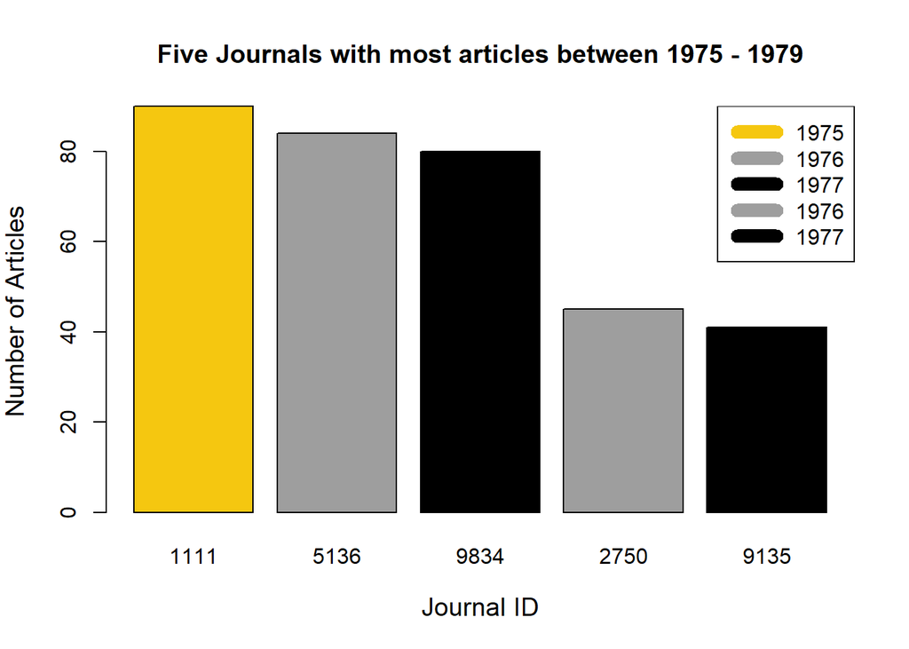

```r
j_qry <- "SELECT jid as Journal_ID,jtitle as Journal_Title, year as Year, Article_count FROM journalfact jf inner join date_dim on date_dim.date_id = jf.date_id WHERE year BETWEEN 1975 AND 1979  ORDER BY Article_count DESC LIMIT 5"
journals <- dbGetQuery(dbConnectionMysql,j_qry)
View(journals)

H <- journals$Article_count
M <- journals$Journal_ID
Y <- journals$Year

# Plot the bar chart
barplot(H,names.arg=M,xlab="Journal ID",ylab="Number of Articles",main="Five Journals with most articles between 1975 - 1979",col = Y, legend.text = TRUE, args.legend = list(x = "topright",bty="n"),cex.lab = 1.2)

legend("topright", legend = Y,col=Y,lwd=10)
```

```r
rmarkdown::paged_table(journals)
```

| Journal_ID | Journal_Title | Year | Article_count |
| --- | --- | --- | --- |
| 1111 | The Journal of pharmacy and pharmacology | 1975 | 90 |
| 5136 | The Journal of pharmacy and pharmacology | 1976 | 84 |
| 9834 | The Journal of pharmacy and pharmacology | 1977 | 80 |
| 2750 | The Journal of pharmacy and pharmacology | 1976 | 45 |
| 9135 | The Journal of pharmacy and pharmacology | 1977 | 41 |

### Description :

#### The above table and the bar chart gives the top five journals with most articles between the period 1975-1979.Visualization was chosen instead of tables as this seemed better approach in this use case as the data to be displayed is small and concise and is well understood when visualized. The table is also shown to show the mapping between journal Ids and journal titles.

# Report

## Number of articles per journal per year broken down by quarter, where in each table represents one quarter

## Date : 20 April 2023

### Journals per year for Quarter 1

```r
j_qry1 <- "SELECT jid as Journal_ID,jtitle as Journal_Title, year as Year, Article_count,Quarter FROM journalfact jf inner join date_dim on date_dim.date_id = jf.date_id WHERE Quarter=1"
quarter1_journals <- dbGetQuery(dbConnectionMysql,j_qry1)
rmarkdown::paged_table(quarter1_journals)
```

| Journal_ID | Journal_Title | Year | Article_count | Quarter |
| --- | --- | --- | --- | --- |
| 15 | British journal of haematology | 1975 | 1 | 1 |
| 44 | Bulletin de physio-pathologie respiratoire | 1975 | 1 | 1 |
| 45 | British journal of pharmacology | 1975 | 8 | 1 |
| 364 | Revista de medicina interna, neurologie, psihiatrie, neurochirurgie, dermato-venerologie. Neurologie, psihiatrie, neurochirurgie | 1975 | 1 | 1 |
| 365 | Scandinavian journal of dental research | 1975 | 2 | 1 |
| 397 | Ukrains'kyi biokhimichnyi zhurnal | 1975 | 5 | 1 |
| 500 | Bollettino chimico farmaceutico | 1975 | 1 | 1 |
| 826 | Surgery, gynecology & obstetrics | 1975 | 1 | 1 |
| 852 | Voprosy pitaniia | 1975 | 1 | 1 |
| 861 | Zhurnal vysshei nervnoi deiatelnosti imeni I P Pavlova | 1975 | 1 | 1 |

[output cut: 2694 more lines]

```r
View(quarter1_journals)
```

### Journals per year for Quarter 2

```r
j_qry2 <- "SELECT jid as Journal_ID,jtitle as Journal_Title, year as Year, Article_count,Quarter FROM journalfact jf inner join date_dim on date_dim.date_id = jf.date_id WHERE Quarter=2"
quarter2_journals <- dbGetQuery(dbConnectionMysql,j_qry2)
rmarkdown::paged_table(quarter2_journals)
```

| Journal_ID | Journal_Title | Year | Article_count | Quarter |
| --- | --- | --- | --- | --- |
| 37 | Biulleten' eksperimental'noi biologii i meditsiny | 1975 | 4 | 2 |
| 66 | Comptes rendus hebdomadaires des seances de l'Academie des sciences. Serie D: Sciences naturelles | 1975 | 2 | 2 |
| 139 | Immunochemistry | 1975 | 1 | 2 |
| 205 | Taiwan yi xue hui za zhi. Journal of the Formosan Medical Association | 1975 | 2 | 2 |
| 313 | Pflugers Archiv : European journal of physiology | 1975 | 1 | 2 |
| 326 | Proceedings of the Royal Society of Medicine | 1975 | 2 | 2 |
| 418 | Zeitschrift fur die gesamte innere Medizin und ihre Grenzgebiete | 1975 | 1 | 2 |
| 667 | The Journal of experimental biology | 1975 | 1 | 2 |
| 773 | Pflugers Archiv : European journal of physiology | 1975 | 1 | 2 |
| 871 | Igaku kenkyu. Acta medica | 1975 | 1 | 2 |

[output cut: 3040 more lines]

```r
View(quarter2_journals)
```

### Journals per year for Quarter 3

```r
j_qry3 <- "SELECT jid as Journal_ID,jtitle as Journal_Title, year as Year, Article_count,Quarter FROM journalfact jf inner join date_dim on date_dim.date_id = jf.date_id WHERE Quarter=3"
quarter3_journals <- dbGetQuery(dbConnectionMysql,j_qry3)
rmarkdown::paged_table(quarter3_journals)
```

| Journal_ID | Journal_Title | Year | Article_count | Quarter |
| --- | --- | --- | --- | --- |
| 12 | The British journal of clinical practice | 1975 | 1 | 3 |
| 13 | The British journal of dermatology | 1975 | 1 | 3 |
| 32 | Biofizika | 1975 | 2 | 3 |
| 42 | British journal of plastic surgery | 1975 | 1 | 3 |
| 54 | Brookhaven symposia in biology | 1975 | 1 | 3 |
| 82 | Critical care medicine | 1975 | 1 | 3 |
| 83 | Current problems in clinical biochemistry | 1975 | 1 | 3 |
| 89 | Der Chirurg; Zeitschrift fur alle Gebiete der operativen Medizen | 1975 | 1 | 3 |
| 91 | Doklady Akademii nauk SSSR | 1975 | 2 | 3 |
| 102 | European journal of biochemistry | 1975 | 5 | 3 |

[output cut: 3122 more lines]

```r
View(quarter3_journals)
```

### Journals per year for Quarter 4

```r
j_qry4 <- "SELECT jid as Journal_ID,jtitle as Journal_Title, year as Year, Article_count,Quarter FROM journalfact jf inner join date_dim on date_dim.date_id = jf.date_id WHERE Quarter=4"
quarter4_journals <- dbGetQuery(dbConnectionMysql,j_qry4)
rmarkdown::paged_table(quarter4_journals)
```

| Journal_ID | Journal_Title | Year | Article_count | Quarter |
| --- | --- | --- | --- | --- |
| 2 | Biochemical and biophysical research communications | 1975 | 3 | 4 |
| 3 | Biochemical and biophysical research communications | 1975 | 2 | 4 |
| 8 | Biochemical pharmacology | 1975 | 3 | 4 |
| 14 | The British journal of dermatology | 1975 | 1 | 4 |
| 33 | Biophysical chemistry | 1975 | 1 | 4 |
| 34 | Biofizika | 1975 | 1 | 4 |
| 38 | Bulletin of environmental contamination and toxicology | 1975 | 1 | 4 |
| 43 | British journal of pharmacology | 1975 | 1 | 4 |
| 46 | British journal of urology | 1975 | 1 | 4 |
| 47 | The British journal of surgery | 1975 | 1 | 4 |

[output cut: 4975 more lines]

```r
View(quarter4_journals)
```

### Description:

#### For this use case displaying data in table is better as there are huge number of records. Accomodating 10000 records in a single view by visualization is difficult. Hence tables are used. It gives the number of articles per journal per quarter. First table gives information for first quarter, second table for 2nd quarter, third table for third quarter and fourth table for 4th quarter.